# Statistics in R

MRC London Institute of Medical Sciences (http://bioinformatics.lms.mrc.ac.uk)  
25/Sep/2018

### Outline

- data summary
- hypothesis testing
- correlation, linear regression and ANOVA
- we only have 1 hour and 45 minutes…

### Materials.

All prerequisites, links to material and slides for this course can be found on github.

- [StatisticsInR](http://mrccsc.github.io/StatisticsInR/)

Or can be downloaded as a zip archive from here.

- [Download zip](https://github.com/mrccsc/StatisticsInR/zipball/master)

### Materials. - Presentations, source code and practicals.

Once the zip files are unzipped, all presentations are available as HTML slides and pages. Practical sheets will be available in the directories underneath.

- **exercises/** Practicals as HTML pages.
- **answers/** Practicals with answers as HTML pages.

### Set the Working directory

Before running any of the code in the practicals or slides we need to set the working directory to the folder we unarchived.

You may navigate to the unarchived Reproducible-R folder in the Rstudio menu

**Session -> Set Working Directory -> Choose Directory**

or in the console.

```r
setwd("/Users/yfwang27/workfromhome/workshop/StatisticsR_CBW18")
# e.g. setwd("~/Downloads/StatisticsInR/Statistics2016")
```

### Case study

Start from some data for mouse strain BKS.Cg-Dock7m +/+ Leprdb/J (db/db)

Data Source: Jackson Laboratory

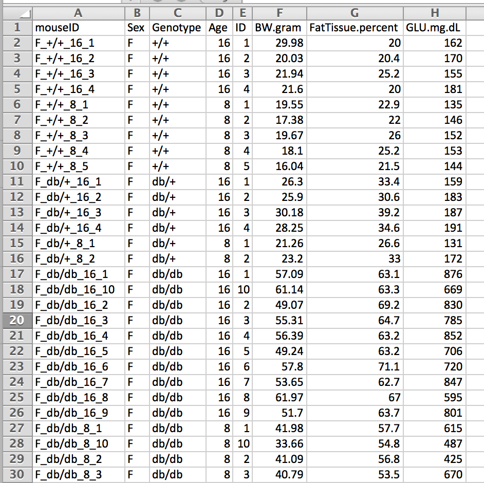

### Save excel file as csv file

[figure not shown]

### We don't need a pretty excel file for the csv format

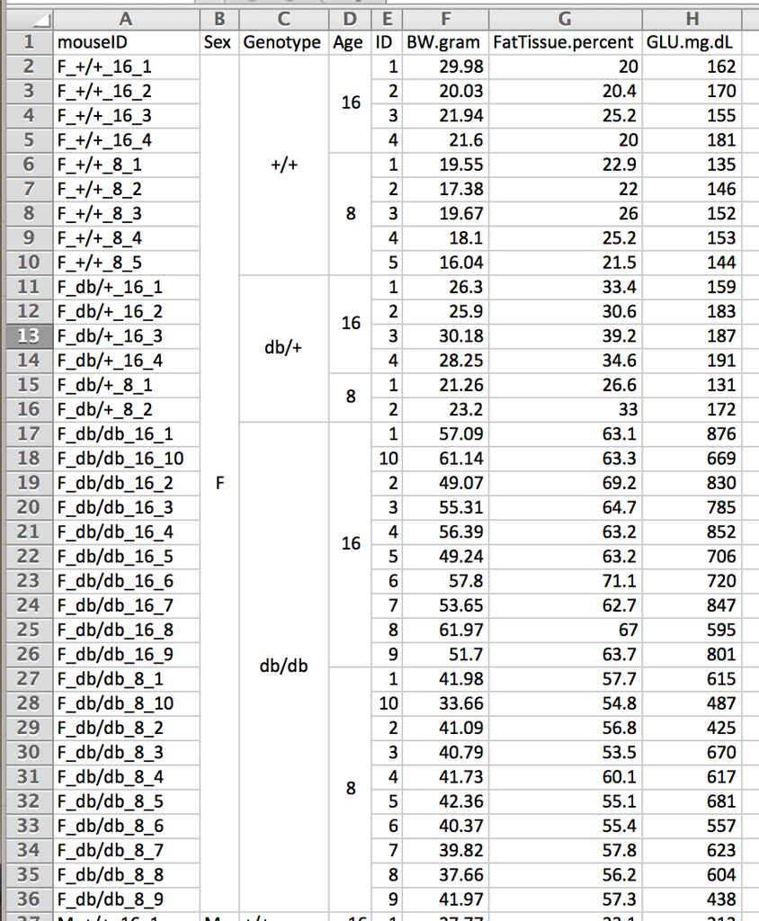

### Load data

```r
> alldata<-read.csv(file="data/mouse_BW_Fat_Glu_info.csv")
```

### Data summary

- data type
- spread of data
- shape of data
- distribution

### Data type

data type

- continuous

eg. blood pressure, body weight, height …

- discrete

eg. gender, hair colour, RNA-seq read count…

### Recap some basic R functions (1/7)

- **str()**, **head()**, **dim()**, **colnames()** and **summary()** functions
- more details please see [Reproducible R course](http://mrccsc.github.io/Reproducible-R/)

– [Data types in R](http://mrccsc.github.io/Reproducible-R/r_course/presentations/slides/introToR_Session1.html#/datatypes)

### Recap some basic R functions (2/7)

**head()**: See the first 6 lines of an R object

```r
> head(alldata)
```

```
     mouseID Sex Genotype Age ID BW.gram FatTissue.percent GLU.mg.dL
1 F_+/+_16_1   F      +/+  16  1   29.98              20.0       162
2 F_+/+_16_2   F      +/+  16  2   20.03              20.4       170
3 F_+/+_16_3   F      +/+  16  3   21.94              25.2       155
4 F_+/+_16_4   F      +/+  16  4   21.60              20.0       181
5  F_+/+_8_1   F      +/+   8  1   19.55              22.9       135
6  F_+/+_8_2   F      +/+   8  2   17.38              22.0       146
```

### Recap some basic R functions (3/7)

see the how many rows and columns in “alldata” object

```r
> dim(alldata)
```

```
[1] 74  8
```

see column names of “alldata”

```r
> colnames(alldata)
```

```
[1] "mouseID"           "Sex"               "Genotype"
[4] "Age"               "ID"                "BW.gram"
[7] "FatTissue.percent" "GLU.mg.dL"
```

### Recap some basic R functions (4/7)

**str()**: Compactly display the internal structure of an R object

Make sure the data format is correct for each column.

```r
> str(alldata)
```

```
'data.frame':   74 obs. of  8 variables:
 $ mouseID          : Factor w/ 74 levels "F_+/+_16_1","F_+/+_16_2",..: 1 2 3 4 5 6 7 8 9 10 ...
 $ Sex              : Factor w/ 2 levels "F","M": 1 1 1 1 1 1 1 1 1 1 ...
 $ Genotype         : Factor w/ 3 levels "+/+","db/+","db/db": 1 1 1 1 1 1 1 1 1 2 ...
 $ Age              : int  16 16 16 16 8 8 8 8 8 16 ...
 $ ID               : int  1 2 3 4 1 2 3 4 5 1 ...
 $ BW.gram          : num  30 20 21.9 21.6 19.6 ...
 $ FatTissue.percent: num  20 20.4 25.2 20 22.9 22 26 25.2 21.5 33.4 ...
 $ GLU.mg.dL        : int  162 170 155 181 135 146 152 153 144 159 ...
```

### Recap some basic R functions (5/7)

```r
> summary(alldata)
```

```
       mouseID   Sex     Genotype       Age           ID
 F_+/+_16_1: 1   F:35   +/+  :19   Min.   : 8   Min.   : 1.00
 F_+/+_16_2: 1   M:39   db/+ :15   1st Qu.: 8   1st Qu.: 2.00
 F_+/+_16_3: 1          db/db:40   Median :12   Median : 4.00
 F_+/+_16_4: 1                     Mean   :12   Mean   : 4.23
 F_+/+_8_1 : 1                     3rd Qu.:16   3rd Qu.: 6.00
 F_+/+_8_2 : 1                     Max.   :16   Max.   :10.00
 (Other)   :68
    BW.gram      FatTissue.percent   GLU.mg.dL
 Min.   :16.04   Min.   :20.00     Min.   :131.0
 1st Qu.:26.87   1st Qu.:26.70     1st Qu.:195.8
 Median :38.15   Median :54.15     Median :509.0
 Mean   :37.36   Mean   :44.91     Mean   :448.1
 3rd Qu.:47.80   3rd Qu.:60.70     3rd Qu.:664.2
 Max.   :61.97   Max.   :71.10     Max.   :876.0
```

### Recap some basic R functions (6/7)

```r
> alldata$Age<-as.factor(alldata$Age)
> summary(alldata)
```

```
       mouseID   Sex     Genotype  Age           ID           BW.gram
 F_+/+_16_1: 1   F:35   +/+  :19   8 :37   Min.   : 1.00   Min.   :16.04
 F_+/+_16_2: 1   M:39   db/+ :15   16:37   1st Qu.: 2.00   1st Qu.:26.87
 F_+/+_16_3: 1          db/db:40           Median : 4.00   Median :38.15
 F_+/+_16_4: 1                             Mean   : 4.23   Mean   :37.36
 F_+/+_8_1 : 1                             3rd Qu.: 6.00   3rd Qu.:47.80
 F_+/+_8_2 : 1                             Max.   :10.00   Max.   :61.97
 (Other)   :68
 FatTissue.percent   GLU.mg.dL
 Min.   :20.00     Min.   :131.0
 1st Qu.:26.70     1st Qu.:195.8
 Median :54.15     Median :509.0
 Mean   :44.91     Mean   :448.1
 3rd Qu.:60.70     3rd Qu.:664.2
 Max.   :71.10     Max.   :876.0
```

### Recap some basic R functions (7/7)

**ftable()**: Create ‘flat’ contingency tables

```r
ftable(alldata[,c("Age","Genotype")])
```

```
    Genotype +/+ db/+ db/db
Age
8             10    7    20
16             9    8    20
```

### Spread of data - working with plots (boxplot)

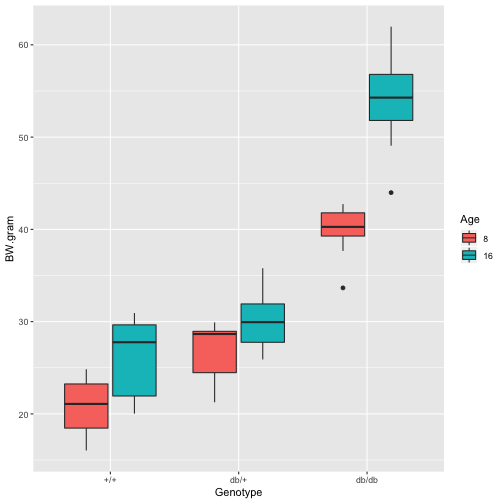

```r
> library(ggplot2)
> ggplot(alldata, aes(x=Genotype, y=BW.gram, fill=Age)) + geom_boxplot()
```

### Shape of data - working with plots 2 (Violin plot)

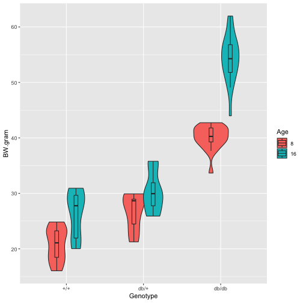

```r
> library(ggplot2)
> ggplot(alldata, aes(x=Genotype, y=BW.gram, fill=Age)) + geom_violin(position=position_dodge(width = 0.5)) +geom_boxplot(width=.1, outlier.colour=NA,position=position_dodge(width = 0.5))
```

### Spread of data - use body weight from WT mice (1/4)

- working with plots
- more details please see [Reproducible R course](http://mrccsc.github.io/Reproducible-R/)

–[Plotting in R](http://mrccsc.github.io/Reproducible-R/r_course/presentations/slides/introToR_Session1.html#/plotting)

```r
> WT_data<-alldata[alldata$Genotype=="+/+",]
> WT_data$BW.gram
```

```
 [1] 29.98 20.03 21.94 21.60 19.55 17.38 19.67 18.10 16.04 27.77 30.93
[12] 29.28 26.57 29.65 22.49 23.45 24.84 23.20 23.26
```

### Spread of data - useful functions (2/4)

**min()**, **max()**, **median()**, **range()** and **quantile()** functions

```r
> min.BW.gram<-min(WT_data$BW.gram)
> max.BW.gram<-max(WT_data$BW.gram)
> median.BW.gram<-median(WT_data$BW.gram)
> mean.BW.gram<-mean(WT_data$BW.gram)
> c(min.BW.gram, max.BW.gram, median.BW.gram, mean.BW.gram)
```

```
[1] 16.04000 30.93000 23.20000 23.45947
```

```r
> range(WT_data$BW.gram)
```

```
[1] 16.04 30.93
```

```r
> quantile(WT_data$BW.gram)
```

```
   0%   25%   50%   75%  100%
16.04 19.85 23.20 27.17 30.93
```

### Spread of data - work with plots (3/4)

Boxplot

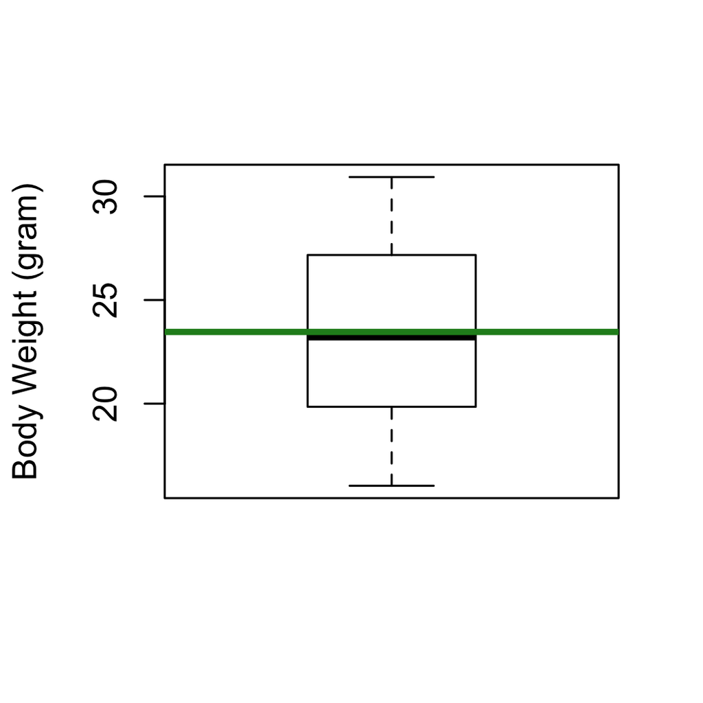

```r
> c(min.BW.gram, max.BW.gram)
```

```
[1] 16.04 30.93
```

```r
> c(median.BW.gram, mean.BW.gram)
```

```
[1] 23.20000 23.45947
```

```r
> quantile(WT_data$BW.gram)[c(2,4)]
```

```
  25%   75%
19.85 27.17
```

### Spread of data - work with plots (4/4)

**summary()**

```r
> summary(WT_data$BW.gram)
```

```
   Min. 1st Qu.  Median    Mean 3rd Qu.    Max.
  16.04   19.85   23.20   23.46   27.17   30.93
```

**range()**: show the minimum and maximum

```r
> range(WT_data$BW.gram)
```

```
[1] 16.04 30.93
```

**IQR()**: show the interquartile range, i.e. 3rd quartile - 1st quartile

```r
> IQR(WT_data$BW.gram)
```

```
[1] 7.32
```

### Spread of data - more about boxplot (optional 1/3)

Scatter plot: plot the WT mice's Body Weight against index

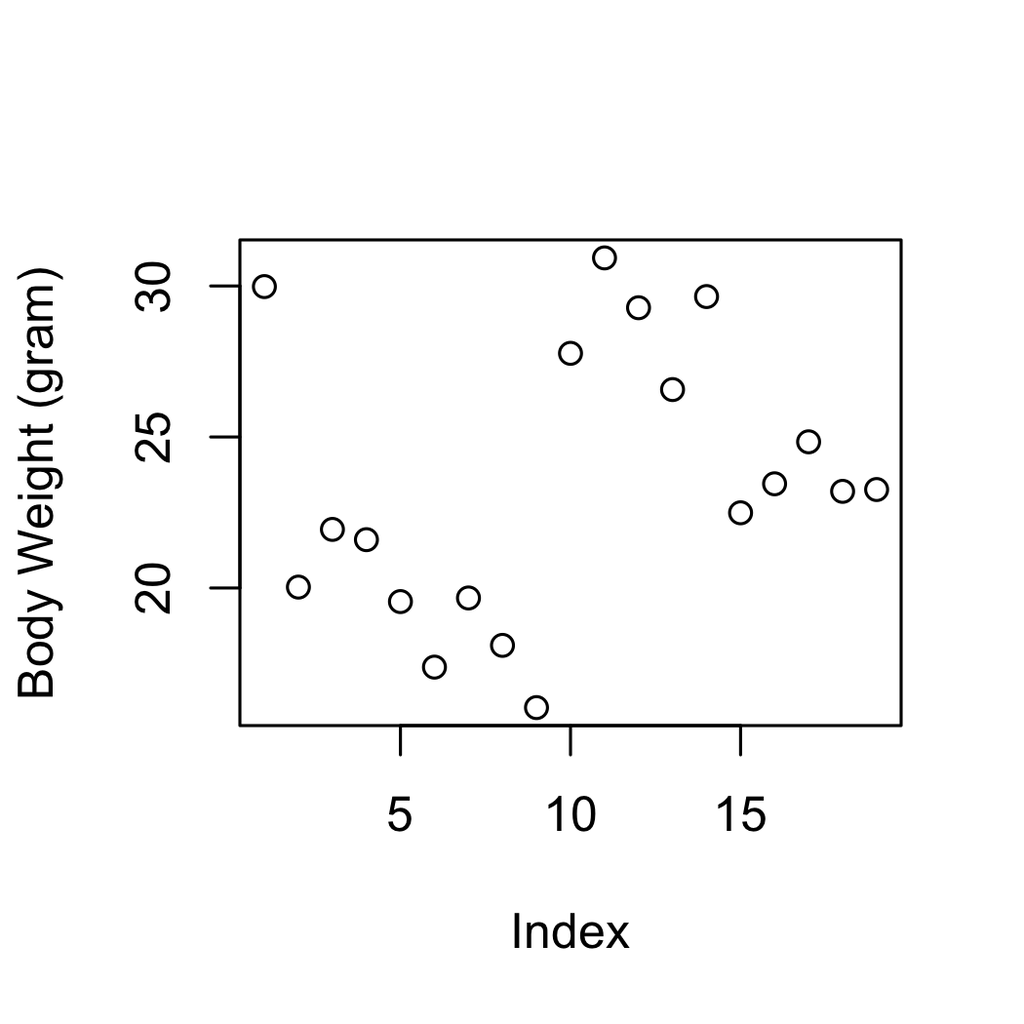

```r
> plot(WT_data$BW.gram,ylab="Body Weight (gram)")
```

### Spread of data - work with plots (optional 2/3)

sort the data from min to max

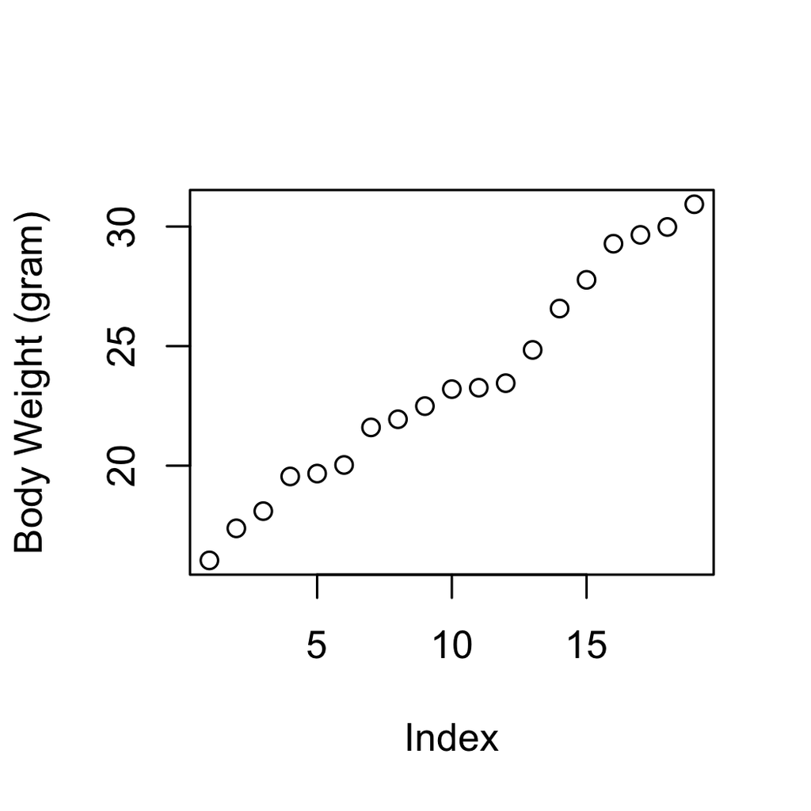

start to see something here…

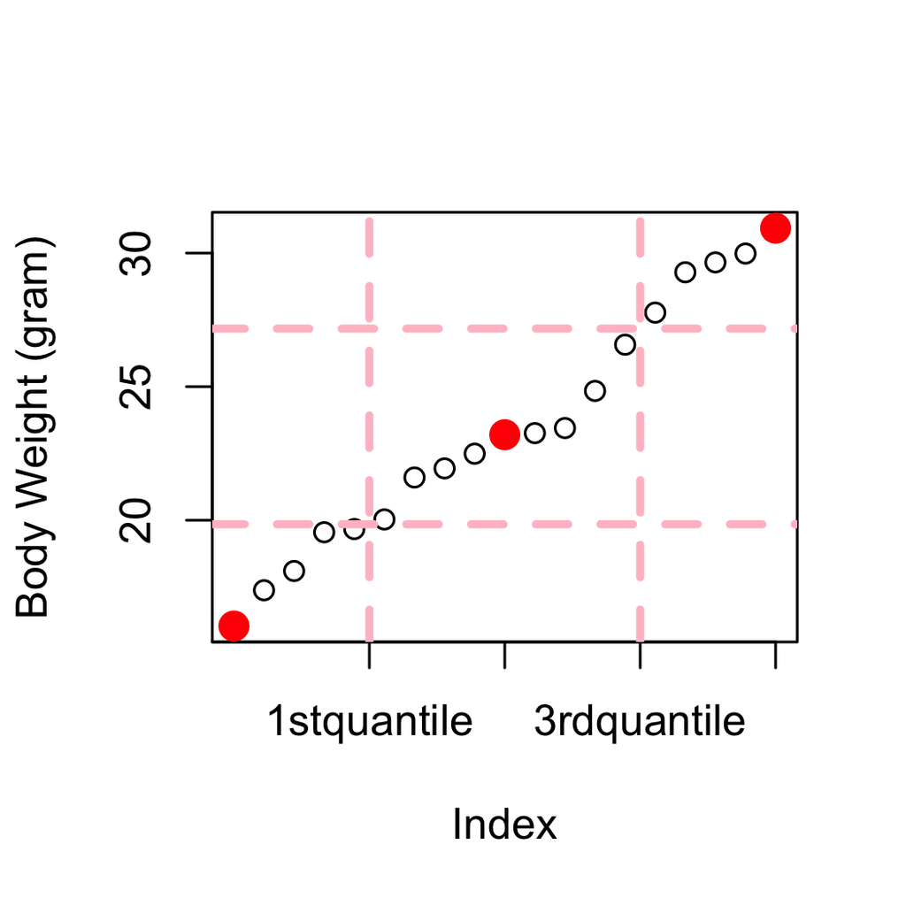

### Spread of data - work with plots (optional 3/3)

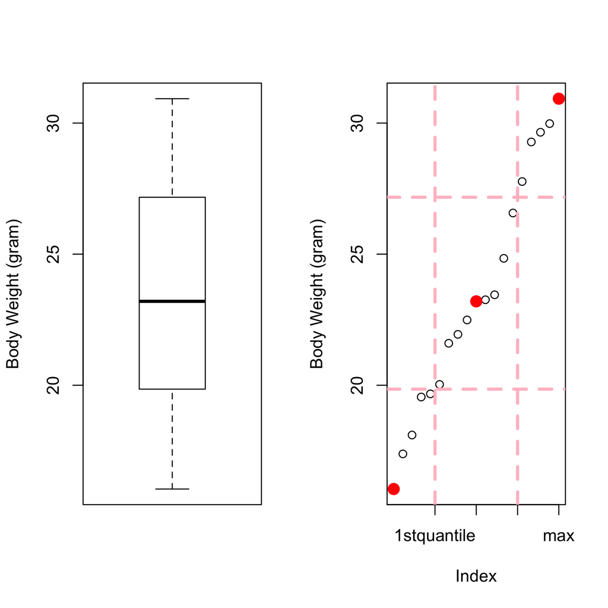

### Data shape - histogram (1/4)

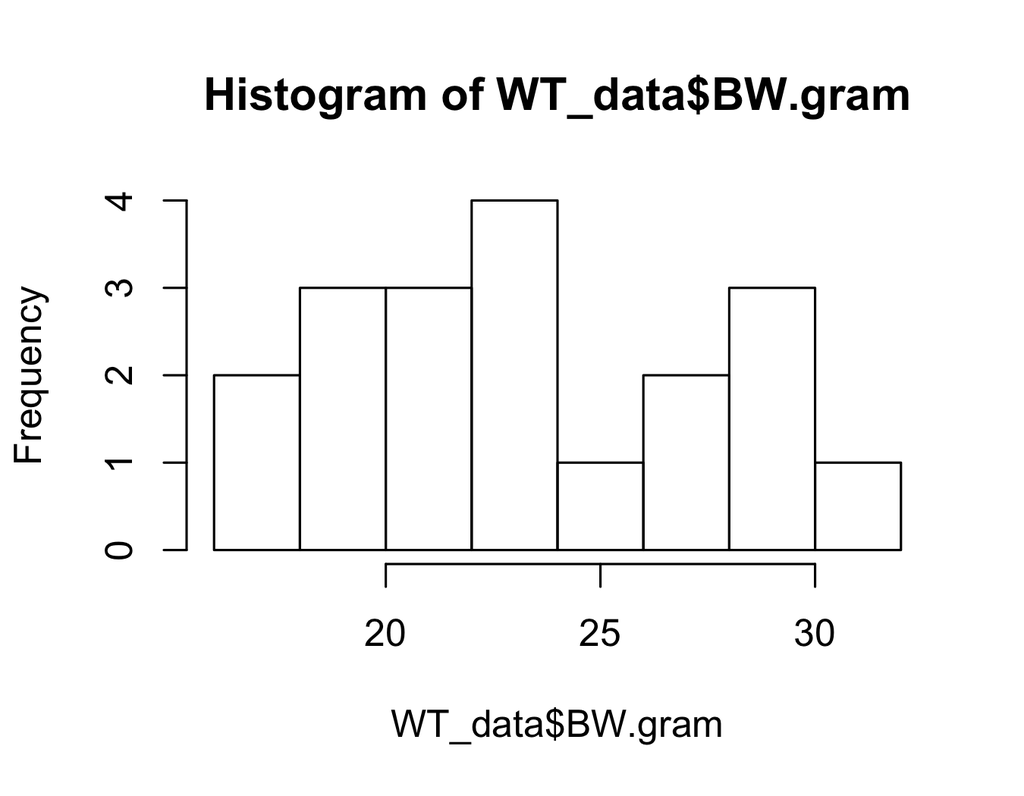

```r
> hist(WT_data$BW.gram,breaks=10)
```

### Data shape - histogram (2/4)

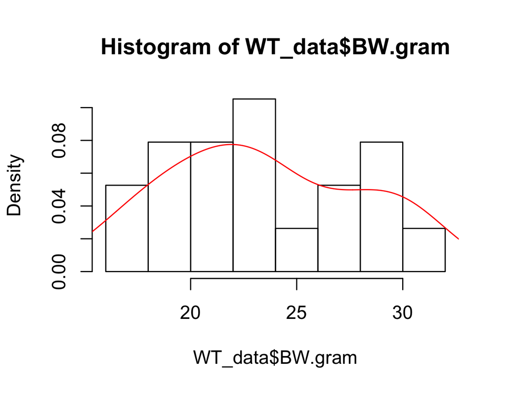

```r
> hist(WT_data$BW.gram,breaks=10,freq = F)
> lines(density(WT_data$BW.gram),col="red")
```

### Data shape - histogram (3/4)

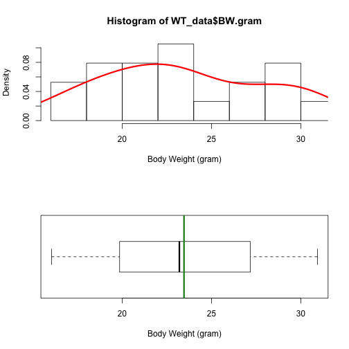

### Data shape - violin plot (4/4)

[figure not shown]

### Spread of data - Variance and Standard deviation (1/3)

\[ \begin{aligned} \overline x = \frac{{\displaystyle\sum_{i=1}^n}x_i}n \\ \\ \\ \text{Variance} = \sigma^2 = \frac{{\displaystyle\sum_{i=1}^n}(\left|x_i-\overline x\right|)^2}{n-1} \\ \\ \\ \text{Standard deviation} = \sigma =\sqrt{\text{Variance}} \\ \\ \\ \end{aligned} \]

```r
> var.BW.gram<-sum((WT_data$BW.gram-mean.BW.gram)^2)/(nrow(WT_data)-1)
> sd.BW.gram<-sqrt(var.BW.gram)
> c(var.BW.gram, sd.BW.gram)
```

```
[1] 20.53558  4.53162
```

### Spread of data - var() and sd() function (2/3)

```r
> var(WT_data$BW.gram)
```

```
[1] 20.53558
```

```r
> sd(WT_data$BW.gram)
```

```
[1] 4.53162
```

### More about SD and Variance (3/3)

- we use the SD more often because it has the same units as the data BUT, if you know one, then you automatically know the other as well.
- in many analysis, variances are used more often, i.e. F-test

### Hypothesis testing and ANOVA

- SD (standard deviation) and SE (standard error; standard error of sample mean)
- Confidence Interval (CI)
- Hypothesis testing

  – parametric test:e.g. t-test

  – non-parametric test: e.g. Wilcoxon test; chi-square test and Fisher's exact test
- Analysis of Variance (ANOVA)

### Statistical tests

On top of descriptive statistics, R has several statistical tests covering a range of problems and data types.

Some common tests include:

- var.test() - Comparing 2 variances (Fisher's F test)
- t.test() - Comparing 2 sample means with normal errors (Student's t-test)
- wilcox.test() - Comparing 2 means with non-normal errors (Wilcoxon's rank test)
- fisher.test() - Testing for independence of 2 variables in a contingency table (Fisher's exact test)

### Hypothesis testing for mean - t-test (1/8)

**t.test()**

*one-sample t-test*

```r
t.test(groupA,mu=something)
```

*independent t-test*

We are going to discuss this case here.

```r
t.test(groupA,groupB,paired=FALSE)
```

*paired t-test*

```r
t.test(Patients_before_treatment,Patients_after_treatment,paired=TRUE)
```

### Hypothesis testing for mean - Load data (2/8)

Use the WT dataset as example: Is the body weight of WT in Age 8 weeks and Age 16 weeks different. For the purpose of this session, let's assume the mouse body weight is normally distributed in WT 8 weeks and WT 16 weeks.

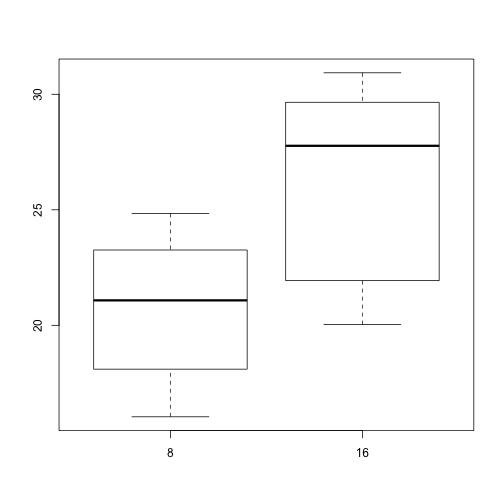

```r
WT_data<-alldata[alldata$Genotype=="+/+",]
boxplot(BW.gram~Age,data=WT_data)
```

### Independent t-test example - Calculating variance (3/8)

What is the difference in variances between WT Age 8 weeks and WT Age 16 weeks?

F test

\[ F= \frac{S^2_x}{S^2_y} \\ S^2_x:\text{ sample varience for group x} \\ S^2_y:\text{ sample varience for gorup y} \\\\ \text{degrees of freedom for the numerator}=n_x-1 \\ \text{degrees of freedom for the denominator}=n_y-1 \]

### Calculating F test with R (4/8)

We can test for any differences in variances between WT 8 weeks and WT 16 weeks with an F-test using the var.test() function.

\[ H_0:\sigma_{WT_8w}^{2}= \sigma_{WT_16w}^{2} \\ H_a:\sigma_{WT_8w}^{2}\neq \sigma_{WT_16w}^{2} \]

```r
WT_8w_data<-WT_data[WT_data$Age=="8" ,]
WT_16w_data<-WT_data[WT_data$Age=="16" ,]
var.test(WT_8w_data$BW.gram,WT_16w_data$BW.gram)
```

```
    F test to compare two variances

data:  WT_8w_data$BW.gram and WT_16w_data$BW.gram
F = 0.53289, num df = 9, denom df = 8, p-value = 0.3673
alternative hypothesis: true ratio of variances is not equal to 1
95 percent confidence interval:
 0.1223004 2.1858962
sample estimates:
ratio of variances
         0.5328912
```

### R objects (s3 and s4) (5/8)

In R, special objects (S3 or S4 objects) can be created which have methods associated to them. The result from var.test is an object of class htest.

Since we have not come across this before, in order to discover its structure we can use the str() function with the object of interest as the argument.

```r
result <- var.test(WT_8w_data$BW.gram,WT_16w_data$BW.gram)
str(result)
```

```
List of 9
 $ statistic  : Named num 0.533
  ..- attr(*, "names")= chr "F"
 $ parameter  : Named int [1:2] 9 8
  ..- attr(*, "names")= chr [1:2] "num df" "denom df"
 $ p.value    : num 0.367
 $ conf.int   : num [1:2] 0.122 2.186
  ..- attr(*, "conf.level")= num 0.95
 $ estimate   : Named num 0.533
  ..- attr(*, "names")= chr "ratio of variances"
 $ null.value : Named num 1
  ..- attr(*, "names")= chr "ratio of variances"
 $ alternative: chr "two.sided"
 $ method     : chr "F test to compare two variances"
 $ data.name  : chr "WT_8w_data$BW.gram and WT_16w_data$BW.gram"
 - attr(*, "class")= chr "htest"
```

### R objects (s3 and s4) (6/8)

Now we know the structure and class of the htest object we can access the slots containing information we want just as with a named list.

The p-value

```r
result$p.value
```

```
[1] 0.3673436
```

The statistic

```r
result$statistic
```

```
        F
0.5328912
```

The data used in function call

```r
result$data.name
```

```
[1] "WT_8w_data$BW.gram and WT_16w_data$BW.gram"
```

### Independent t-test (7/8)

```r
test_res <- t.test(WT_8w_data$BW.gram,WT_16w_data$BW.gram,alternative ="two.sided", var.equal = T)
test_res
```

```
    Two Sample t-test

data:  WT_8w_data$BW.gram and WT_16w_data$BW.gram
t = -3.3985, df = 17, p-value = 0.003419
alternative hypothesis: true difference in means is not equal to 0
95 percent confidence interval:
 -9.106749 -2.130584
sample estimates:
mean of x mean of y
 20.79800  26.41667
```

### T-test example - Specifying a formula (8/8)

The same result to that shown could be achieved by specifying a formula for the comparison. Here we wish to compare 8 weeks versus 16 weeks so we could simply specify the formula and the data to be used.

```r
result_formula <- t.test(BW.gram~Age,WT_data,alternative ="two.sided", var.equal = T)
result_formula
```

```
    Two Sample t-test

data:  BW.gram by Age
t = -3.3985, df = 17, p-value = 0.003419
alternative hypothesis: true difference in means is not equal to 0
95 percent confidence interval:
 -9.106749 -2.130584
sample estimates:
 mean in group 8 mean in group 16
        20.79800         26.41667
```

### Non-parametric test

Non-parametric statistical hypothesis test is a test that is not based on probability distribution for the dependant variable.

It doesn't repuire the dependent varible to be normally distributed.

**wilcox.test()**

Wilcoxon Signed-Rank Test is one of the Non-parametric statistical hypothesis tests. It is a good alternative to t-tests without assuming the dependent variables to follow the normal distribution.

### t-test and Wilcoxon test alternatives

**t.test()**

*one-sample t-test*

```r
t.test(groupA,mu=something)
```

*independent t-test*

```r
t.test(groupA,groupB,paired=FALSE)
```

*paired t-test*

```r
t.test(groupA,groupB,paired=TRUE)
```

**wilcox.test()**

*one-sample Wilcoxon: Signed-Rank Test*

```r
wilcox.test(groupA,mu=something)
```

*Wilcoxon Rank Sum Test: Mann-Whitney U*

```r
wilcox.test(groupA,groupB,paired=FALSE)
```

*paired Wilcoxon:Signed-Rank Test*

```r
wilcox.test(groupA,groupB,paired=TRUE)
```

### Wilcoxon test - wilcox.test()

Wilcoxon Signed-Rank Test is one of the Non-parametric statistical hypothesis tests. It is a good alternative to t-tests without assuming them to follow the normal distribution.

\[ H_0: \text{median}_{a}- \text{median}_{b} = 0 \\ H_a: \text{median}_{a}- \text{median}_{b}\neq 0 \]

### Back to our mouse dataset

Is there body weight different between WT and KO mice?

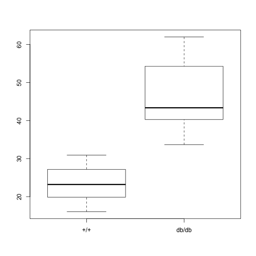

```r
WT_dbdb_data<-alldata[alldata$Genotype!="db/+",]
WT_dbdb_data<-droplevels(WT_dbdb_data)
boxplot(BW.gram~Genotype,data=WT_dbdb_data)
```

### Wilcoxon test

**qqnorm()** and **qqline()**

Check normal distribution with normal quantile plots for WT data

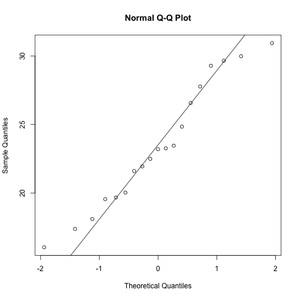

```r
WT4wilcox<-WT_dbdb_data[WT_dbdb_data$Genotype=="+/+",]

qqnorm(WT4wilcox$BW.gram)
qqline(WT4wilcox$BW.gram)
```

```r
shapiro.test(WT4wilcox$BW.gram)
```

```
    Shapiro-Wilk normality test

data:  WT4wilcox$BW.gram
W = 0.95302, p-value = 0.4441
```

### Wilcoxon test

**qqnorm()** and **qqline()**

Check normal distribution with normal quantile plots for db/db data

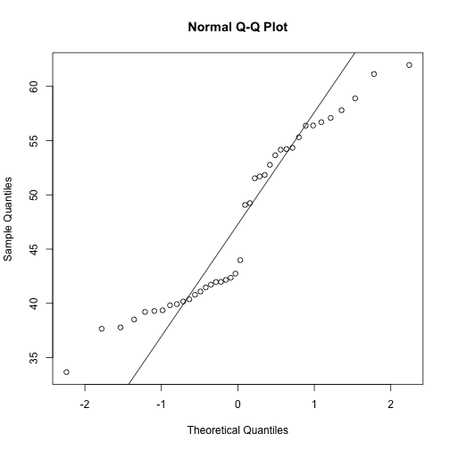

```r
KO4wilcox<-WT_dbdb_data[WT_dbdb_data$Genotype=="db/db",]
qqnorm(KO4wilcox$BW.gram)
qqline(KO4wilcox$BW.gram)
```

```r
shapiro.test(KO4wilcox$BW.gram)
```

```
    Shapiro-Wilk normality test

data:  KO4wilcox$BW.gram
W = 0.90465, p-value = 0.002618
```

### Wilcoxon test (Mann-Whitney U)

**wilcox.test()**

```r
wilcox.test(WT4wilcox$BW.gram,KO4wilcox$BW.gram, paired=F)
```

```
    Wilcoxon rank sum test

data:  WT4wilcox$BW.gram and KO4wilcox$BW.gram
W = 0, p-value = 1.431e-15
alternative hypothesis: true location shift is not equal to 0
```

### fisher.test()

Given two gene lists, tests the significance of their overlap in comparison with a genomic background.

### fisher.test()

create a contigency table

```r
> cmatrix<-matrix(c(5,40,295,19960),byrow=T,ncol=2,dimnames=list(c("In.B","Not.In.B"),c("In.A","Not.In.A")))
> cmatrix
```

```
         In.A Not.In.A
In.B        5       40
Not.In.B  295    19960
```

### fisher.test()

**fisher.test()**

```r
fisher.test(cmatrix)
```

```
    Fisher's Exact Test for Count Data

data:  cmatrix
p-value = 0.0005133
alternative hypothesis: true odds ratio is not equal to 1
95 percent confidence interval:
  2.585939 21.637276
sample estimates:
odds ratio
  8.454877
```

### ANOVA (1/5)

Compute analysis of variance (or deviance), a.k.a. ANOVA, for one or more fitted model objects.

ANOVA is a statistical method that uses F-test to test

\[ H_0:\mu_{1}= \mu_{2}=... \mu_{k} \]

by comparing the variability between groups to the variability within groups

Assume that

(1) all samples are independent and have >2 categorical groups;

(2) dependent variable is continuous

(3) data of each group is normally distributed

(4) homogeneneity of variances

### ANOVA (2/5)

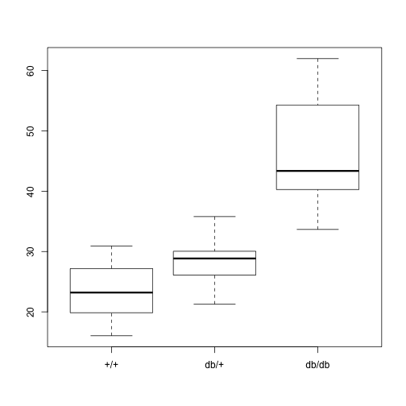

```r
boxplot(BW.gram~Genotype,data=alldata)
```

### ANOVA - use the lm() function (3/5)

```r
lmPG<-lm(formula = BW.gram ~ Genotype,data = alldata)
lmPG
```

```
Call:
lm(formula = BW.gram ~ Genotype, data = alldata)

Coefficients:
  (Intercept)   Genotypedb/+  Genotypedb/db
       23.459          5.131         23.796
```

### ANOVA - use the anova() function (4/5)

```r
anova_PG<-anova(lmPG)
anova_PG
```

```
Analysis of Variance Table

Response: BW.gram
          Df Sum Sq Mean Sq F value    Pr(>F)
Genotype   2 8741.8  4370.9  101.48 < 2.2e-16 ***
Residuals 71 3058.0    43.1
---
Signif. codes:  0 '***' 0.001 '**' 0.01 '*' 0.05 '.' 0.1 ' ' 1
```

### ANOVA - post-hoc analysis (5/5)

**TukeyHSD** - Test which of the groups have different means

```r
TukeyHSD(aov(lmPG))
```

```
  Tukey multiple comparisons of means
    95% family-wise confidence level

Fit: aov(formula = lmPG)

$Genotype
                diff        lwr      upr     p adj
db/+-+/+    5.131193 -0.2950406 10.55743 0.0676741
db/db-+/+  23.796276 19.4190332 28.17352 0.0000000
db/db-db/+ 18.665083 13.9085869 23.42158 0.0000000
```